# pre-assignment

WoodyLIver

27 04 2021

# Libraries

```r
library(openxlsx)
library(tseries)
library(forecast)
library(EnvStats)
library(lmtest)
library(sigmoid)
```

# Read data

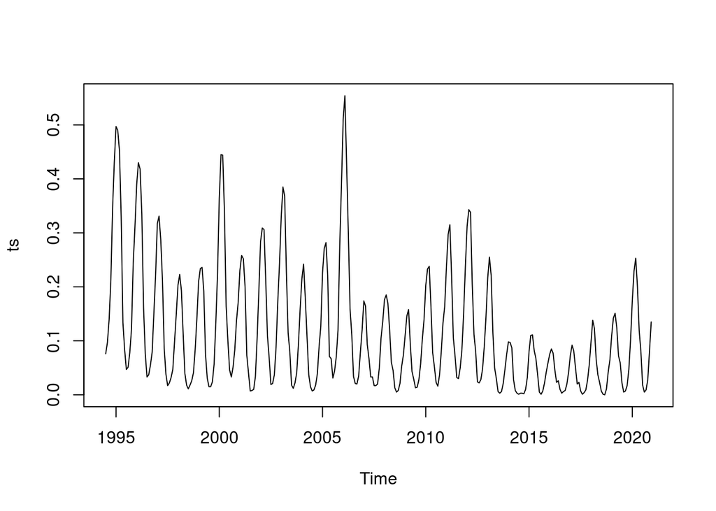

```r
data <- read.xlsx("Lions_Den_data.xlsx")
ts <- ts(unlist(data[2]), start=c(1994, 7), frequency=12)
plot(ts)
```

# Decomposition

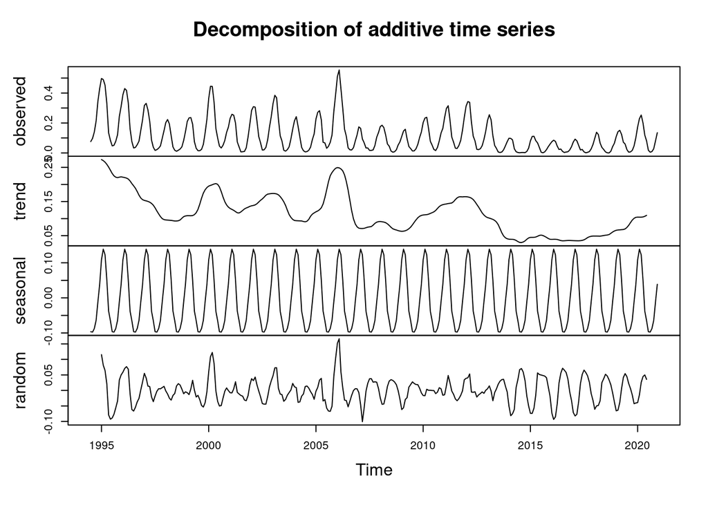

```r
decompose <- decompose(ts, "additive")
plot(decompose)
```

# Outliers

Test on raw data that the winter 2006 does not match. We have tried to manipulate data(differentiation, decomposition, etc) in order to get more outliers, but there were no reasonable results.

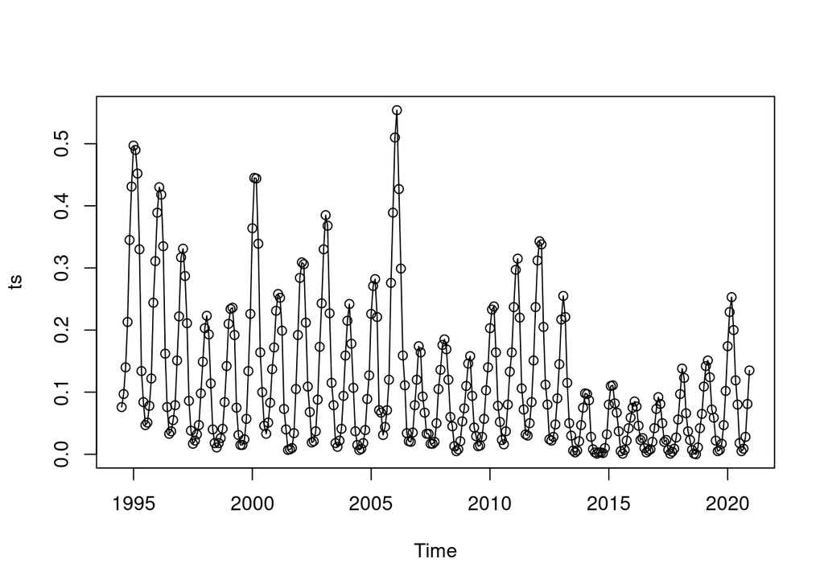

```r
plot(ts, type="o")
```

```r
rosnerTest(ts, k = 3)
```

```
##
## Results of Outlier Test
## -------------------------
##
## Test Method:                     Rosner's Test for Outliers
##
## Hypothesized Distribution:       Normal
##
## Data:                            ts
##
## Sample Size:                     318
##
## Test Statistics:                 R.1 = 3.782021
##                                  R.2 = 3.487550
##                                  R.3 = 3.445420
##
## Test Statistic Parameter:        k = 3
##
## Alternative Hypothesis:          Up to 3 observations are not
##                                  from the same Distribution.
##
## Type I Error:                    5%
##
## Number of Outliers Detected:     1
##
##   i    Mean.i      SD.i Value Obs.Num    R.i+1 lambda.i+1 Outlier
## 1 0 0.1170692 0.1155284 0.554     140 3.782021   3.739949    TRUE
## 2 1 0.1156909 0.1130619 0.510     139 3.487550   3.739067   FALSE
## 3 2 0.1144430 0.1110335 0.497       7 3.445420   3.738181   FALSE
```

# Autocorrelation and stationarity analysis

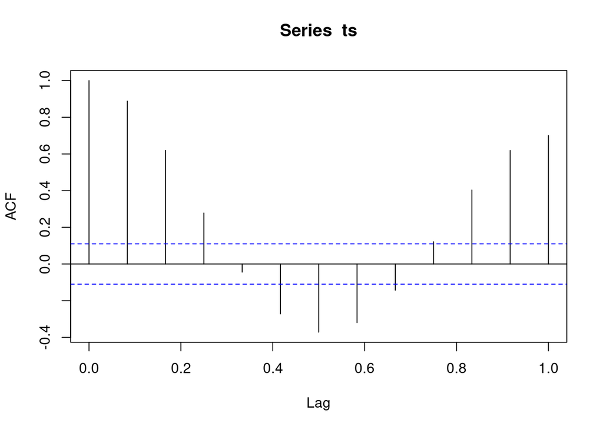

```r
#autocorrelation
acf(ts, lag.max = 12)
```

```r
#stationary test
adf.test(ts)
```

```
##
##  Augmented Dickey-Fuller Test
##
## data:  ts
## Dickey-Fuller = -4.9571, Lag order = 6, p-value = 0.01
## alternative hypothesis: stationary
```

# Delete outlier

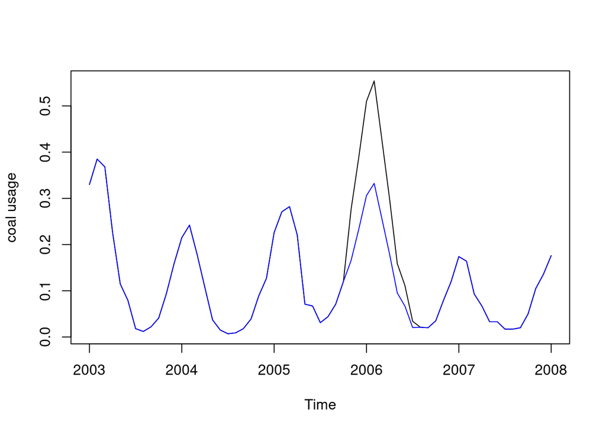

```r
ts_ <- ts
plot(window(ts_, 2003, 2008), type="l", ylab="coal usage")
ts_[137:145] = ts_[137:145] * 0.6
lines(window(ts_, 2003, 2008), type="l", col="blue")
```

# Create model

Model performs decomposition into trend and seasonality, then trend is predicted by ARIMA. Result is a sum of trend prediction and seasonality pushed through relu.

```r
model <- function (ts) {
  decompose_ <- decompose(ts, "additive")
  tsTrend <- ts(decompose_$trend, start=ts, frequency=12)
  fitARIMA <- arima(tsTrend, order=c(1,1,1),seasonal = list(order = c(1,0,0), period = 12),method="ML")
  yTrend <- predict(fitARIMA,n.ahead = 12)$pred
  cTrend <- ts(
    c(tsTrend, yTrend),
    start=start(tsTrend),
    frequency=12
  )
  plot(cTrend, type="s", ylab="coal usage trend")
  ySeasonal <- window(decompose$seasonal, start=end(ts)[1], end=end(ts))
  Y <- ts(as.numeric(yTrend) + as.numeric(ySeasonal),
        start=start(ySeasonal)[1]+1,
        frequency=12)
  Y <- relu(Y)
  TS <- ts(c(ts, Y), start=start(ts), frequency=12)
  plot(TS, type="l", ylab="coal usage",
       main="history and prediction", col="black")
  lines(Y, col="blue")
  print(Y)
  return(Y)
}
```

# Predict

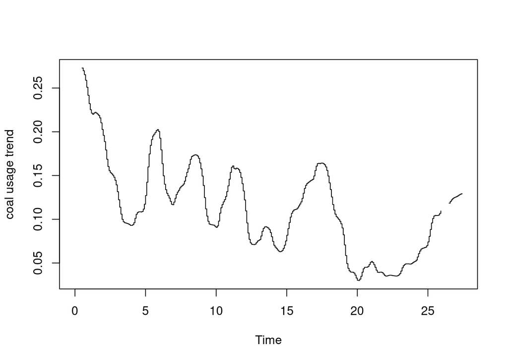

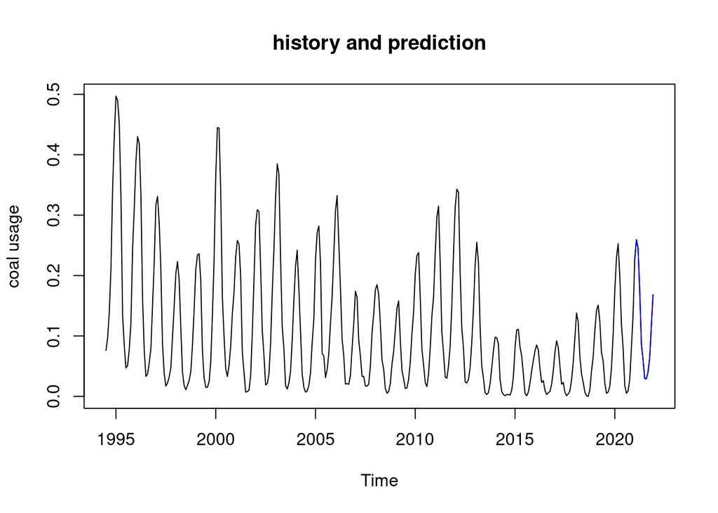

```
##             Jan        Feb        Mar        Apr        May        Jun
## 2021 0.22719068 0.25933252 0.24493153 0.17419903 0.08686344 0.06006777
##             Jul        Aug        Sep        Oct        Nov        Dec
## 2021 0.02937555 0.02900797 0.04012715 0.06425125 0.11783758 0.16806379
```

```
##             Jan        Feb        Mar        Apr        May        Jun
## 2021 0.22719068 0.25933252 0.24493153 0.17419903 0.08686344 0.06006777
##             Jul        Aug        Sep        Oct        Nov        Dec
## 2021 0.02937555 0.02900797 0.04012715 0.06425125 0.11783758 0.16806379
```

```r
model(ts_)
```

# Evaluate

Both, plot and acuracy test shows that our model performs much better than naive method.

```r
arg <- window(ts_, end=c(2019,12))
trg <- window(ts_, start=2020)
ret <- model(arg)
```

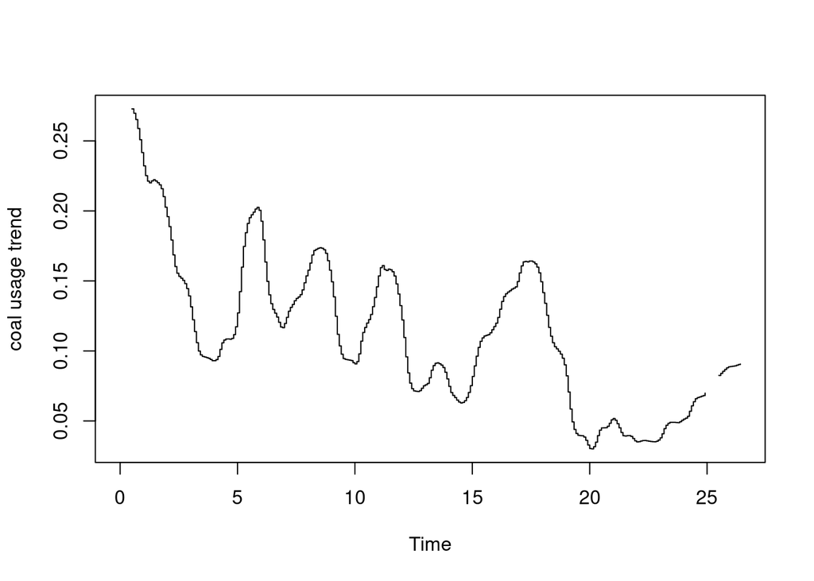

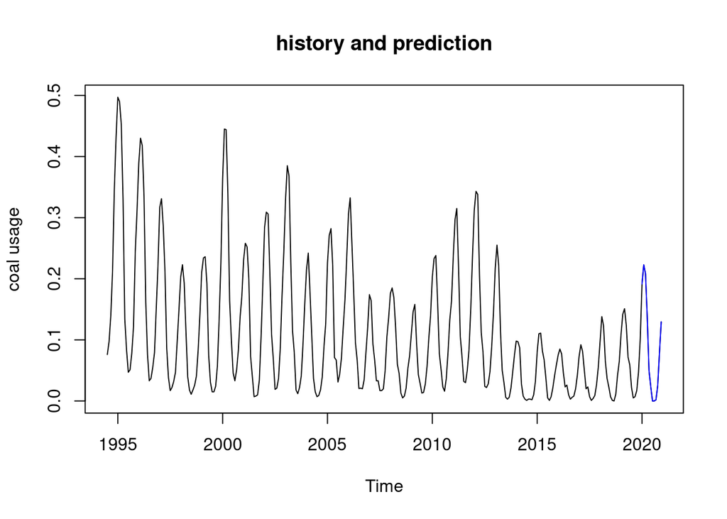

```
##              Jan         Feb         Mar         Apr         May         Jun
## 2020 0.191243014 0.222871632 0.208157240 0.137241529 0.050175519 0.023534018
##              Jul         Aug         Sep         Oct         Nov         Dec
## 2020 0.000000000 0.000000000 0.001965331 0.025700503 0.079150253 0.129369184
```

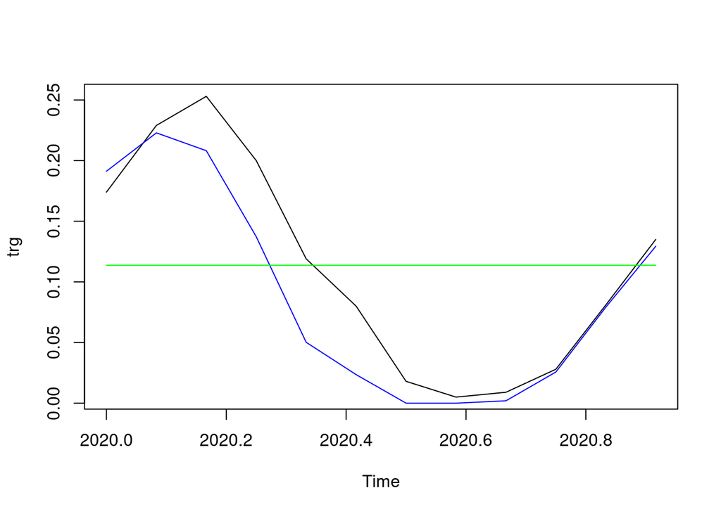

```r
naive <- ts(rep(mean(arg), 12), start=2020, frequency=12)
plot(trg)
lines(ret, col="blue")
lines(naive, col="green")
```

```r
accuracy(naive, trg)
```

```
##                    ME      RMSE        MAE       MPE     MAPE      ACF1
## Test set -0.002787255 0.0845331 0.07408333 -337.8586 371.7638 0.8297481
##          Theil's U
## Test set  7.305112
```

```r
accuracy(ret, trg)
```

```
##                  ME       RMSE        MAE      MPE     MAPE      ACF1 Theil's U
## Test set 0.02179931 0.03493863 0.02467315 38.59319 40.24482 0.6629242 0.4960746
```

## Additional Variables

Knowing the characteristic of the series, it’s seasonality and known specific of coal consumption we can improve our model adding variables of temperature (it is known that higher temperature affects lower coal consumption, also for energy production and building heating) in our country and the share of coal in our energetic mix which can affect future coal consumption. Other variable may be coal price (coal supply might play the same role), but it will somehow correlated with energetic mix and depends on our possibility to swich power source.